# Motor Vehicle Fatality Risk Across the United States

### A Python port of a 2023 state-level investigative analysis

The original work was done in Excel in 2023 and is preserved in `docs/original_report.pdf`. This notebook recreates the same analysis in Python (pandas, matplotlib, statsmodels, scipy) so the methodology is verifiable in code and reproducible from raw data files.

## Question

What state-level factors are associated with motor vehicle fatality risk across the United States, and how strong are those associations?

## Data

Four data sources, all state-level (50 states, one row each), joined into a single modelling panel.

| Variable | Year | Source |
| --- | --- | --- |
| `fatalities_per_100k_1994_2015` (response) | 1994 to 2015 | NHTSA FARS, normalised per 100,000 residents |
| `avg_miles_per_driver_2022` | 2022 | The Zebra, derived from Federal Highway Administration |
| `police_count_2020` | 2020 | Statista |
| `alcohol_gallons_per_capita_2023` | 2023 | World Population Review |
| `pct_pickup_trucks_2022` | 2022 | Industry data |

The response variable is the long-run state-level fatality rate per 100,000 residents averaged over the 22-year window 1994 to 2015. Per-100,000 rather than per-million-vehicle-miles or per-licensed-driver was chosen because it expresses risk in a unit (population) that every resident shares directly, and it produces non-decimal numbers that are easy to compare at a glance.

## Method

For each predictor, fit a simple linear regression against the fatality rate and compute the Pearson correlation. Then fit a joint OLS model on the two strongest single predictors together, and finally a multivariate OLS model with all four predictors to check for confounding.

## Files

- `analysis.ipynb`: this notebook
- `analysis.html`: rendered HTML
- `data/state_panel.csv`: 50-state cross-section, the modelling input
- `data/nhtsa_raw_1994_2015.csv`: raw NHTSA state-year panel (1,100 rows)
- `data/us_fatality_rate_by_year.csv`: US-wide fatality trend 1994 to 2015
- `docs/original_report.pdf`: the 2023 Excel-based original report

```python
import pandas as pd
import numpy as np
import matplotlib.pyplot as plt
import statsmodels.api as sm
from scipy.stats import pearsonr

pd.options.display.float_format = "{:.4f}".format

plt.rcParams["figure.figsize"] = (10, 5.5)
plt.rcParams["axes.grid"] = True
plt.rcParams["grid.color"] = "lightgray"
plt.rcParams["grid.linewidth"] = 0.5
plt.rcParams["axes.spines.top"] = False
plt.rcParams["axes.spines.right"] = False

SCATTER_COLOR = "#4472C4"
LINE_COLOR = "firebrick"
```

## 1. Load the data

```python
panel = pd.read_csv("data/state_panel.csv")
us_trend = pd.read_csv("data/us_fatality_rate_by_year.csv")
nhtsa_raw = pd.read_csv("data/nhtsa_raw_1994_2015.csv")

print(f"State panel: {panel.shape[0]} rows, {panel.shape[1]} columns")
print(f"US trend:    {us_trend.shape[0]} rows")
print(f"NHTSA raw:   {nhtsa_raw.shape[0]} rows (state-year level)")
panel.head()
```

```
State panel: 50 rows, 7 columns
US trend:    22 rows
NHTSA raw:   1100 rows (state-year level)
```

|  | state_name | state_abbr | avg_miles_per_driver_2022 | police_count_2020 | alcohol_gallons_per_capita_2023 | pct_pickup_trucks_2022 | fatalities_per_100k_1994_2015 |
| --- | --- | --- | --- | --- | --- | --- | --- |
| 0 | Alaska | AK | 13090.0000 | 11372 | 2.8500 | 0.3080 | 11.7117 |
| 1 | Alabama | AL | 11111.0000 | 1230 | 1.9900 | 0.2050 | 22.3701 |
| 2 | Arizona | AR | 17224.0000 | 14658 | 2.2500 | 0.1510 | 22.1872 |
| 3 | Arkansas | AZ | 12524.0000 | 6570 | 1.7800 | 0.2430 | 17.9259 |
| 4 | California | CA | 12899.0000 | 93682 | 2.4900 | 0.1170 | 10.4285 |

## 2. Response variable: state-level fatality rate

The response is the average annual fatality rate per 100,000 residents over 1994 to 2015. Sorting from highest to lowest makes the cross-state spread immediately legible: Wyoming sits at almost 30 per 100,000, while Massachusetts and Rhode Island are near 6.

```python
rv = panel["fatalities_per_100k_1994_2015"]
print(f"Mean:   {rv.mean():.4f}")
print(f"Median: {rv.median():.4f}")
print(f"Min:    {rv.min():.4f}  ({panel.loc[rv.idxmin(), 'state_name']})")
print(f"Max:    {rv.max():.4f}  ({panel.loc[rv.idxmax(), 'state_name']})")
```

```
Mean:   15.2100
Median: 14.3784
Min:    6.4032  (Massachusetts)
Max:    29.7071  (Wyoming)
```

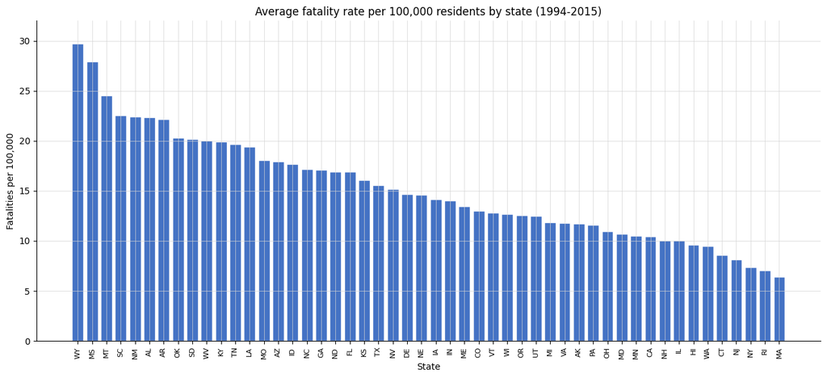

```python
sorted_states = panel.sort_values("fatalities_per_100k_1994_2015", ascending=False)
fig, ax = plt.subplots(figsize=(13, 6))
ax.bar(sorted_states["state_abbr"], sorted_states["fatalities_per_100k_1994_2015"],
       color=SCATTER_COLOR, edgecolor="white")
ax.set_title("Average fatality rate per 100,000 residents by state (1994-2015)", fontsize=12)
ax.set_xlabel("State")
ax.set_ylabel("Fatalities per 100,000")
ax.tick_params(axis="x", rotation=90, labelsize=8)
ax.set_ylim(0, 32)
plt.tight_layout()
plt.show()
```

States at the top of the chart are predominantly rural with sparsely populated road networks. States at the bottom are dense Northeastern states. This urban/rural pattern is the underlying signal that the predictors below try to explain.

## 3. The US-wide trend

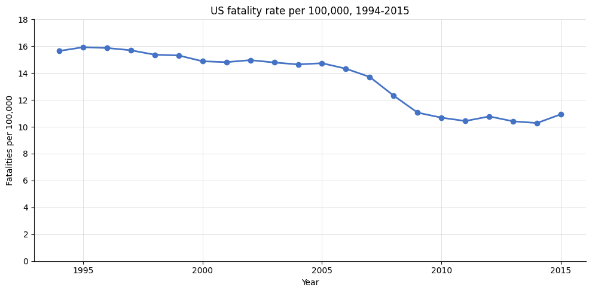

```
Average US rate 1994-2015: 13.5255 per 100K
1994 rate: 15.6479
2015 rate: 10.9336
```

```python
fig, ax = plt.subplots(figsize=(10, 5))
ax.plot(us_trend["year"], us_trend["us_fatality_rate_per_100k"],
        marker="o", color=SCATTER_COLOR, linewidth=2)
ax.set_title("US fatality rate per 100,000, 1994-2015", fontsize=12)
ax.set_xlabel("Year")
ax.set_ylabel("Fatalities per 100,000")
ax.set_ylim(0, 18)
plt.tight_layout()
plt.show()

print(f"Average US rate 1994-2015: {us_trend['us_fatality_rate_per_100k'].mean():.4f} per 100K")
print(f"1994 rate: {us_trend.iloc[0]['us_fatality_rate_per_100k']:.4f}")
print(f"2015 rate: {us_trend.iloc[-1]['us_fatality_rate_per_100k']:.4f}")
```

The national rate fell from roughly 15.6 per 100K in 1994 to about 10.9 in 2015, a 30% improvement spanning two decades of safer vehicles, graduated licensing, seatbelt enforcement, and DUI policy. Within that downward trend, the cross-state spread remained substantial; the analysis below focuses on that spread.

## 4. Single-predictor analysis

```python
def regression_panel(df, x_col, y_col, x_label, title, xfmt=None, eq_xy=(0.05, 0.95)):
    x = df[x_col]
    y = df[y_col]
    r, p_value = pearsonr(x, y)

    X = sm.add_constant(x)
    model = sm.OLS(y, X).fit()
    slope = model.params[x_col]
    intercept = model.params["const"]
    r_squared = model.rsquared

    fig, ax = plt.subplots(figsize=(9, 5.5))
    ax.scatter(x, y, color=SCATTER_COLOR, alpha=0.75, edgecolors="white", s=60)
    x_line = np.linspace(x.min(), x.max(), 100)
    ax.plot(x_line, slope * x_line + intercept, color=LINE_COLOR, linewidth=2)
    ax.set_xlabel(x_label)
    ax.set_ylabel("Fatalities per 100,000")
    ax.set_title(title, fontsize=12)

    eqn_sign = "+" if intercept >= 0 else "-"
    eqn = f"y = {slope:.5g}x {eqn_sign} {abs(intercept):.5g}"
    ax.text(eq_xy[0], eq_xy[1],
            f"{eqn}\nr = {r:.4f}    R² = {r_squared:.4f}    p = {p_value:.4f}",
            transform=ax.transAxes, va="top", fontsize=10,
            bbox=dict(boxstyle="round,pad=0.4", facecolor="white", alpha=0.85, edgecolor="lightgray"))

    if xfmt:
        ax.xaxis.set_major_formatter(plt.FuncFormatter(xfmt))

    plt.tight_layout()
    plt.show()
    return {"r": r, "r_squared": r_squared, "slope": slope, "intercept": intercept, "p_value": p_value}
```

### 4.1 Average miles driven per driver

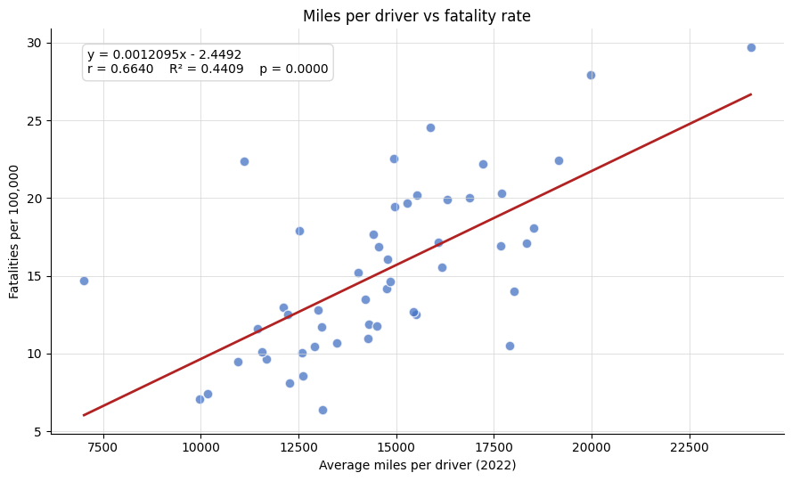

```python
r1 = regression_panel(
    panel, "avg_miles_per_driver_2022", "fatalities_per_100k_1994_2015",
    "Average miles per driver (2022)",
    "Miles per driver vs fatality rate",
)
```

**Medium-strong positive relationship** (r ≈ 0.66, R² ≈ 0.44). Each additional 1,000 miles per driver per year is associated with roughly 1.2 more fatalities per 100,000 residents. States where average drivers spend more time on the road (typically rural states with long inter-town distances) have more exposure and therefore more fatalities. This is the strongest single predictor in the set.

### 4.2 Police force size

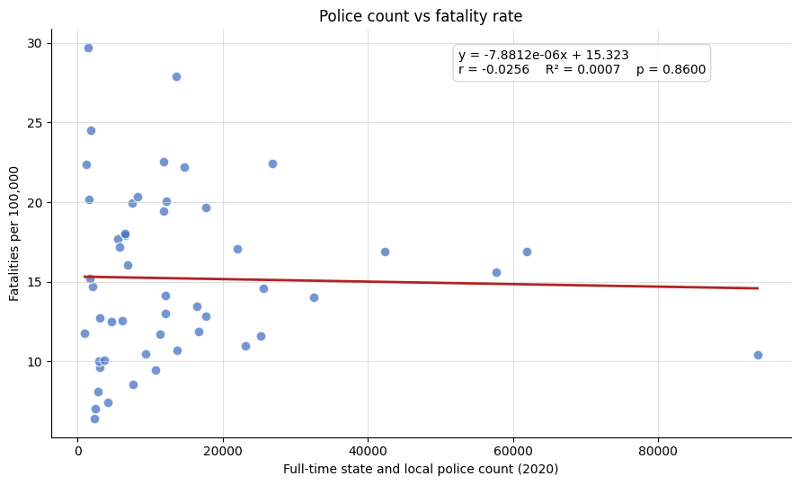

```python
r2 = regression_panel(
    panel, "police_count_2020", "fatalities_per_100k_1994_2015",
    "Full-time state and local police count (2020)",
    "Police count vs fatality rate",
    eq_xy=(0.55, 0.95),
)
```

**Effectively no relationship** (r ≈ -0.03, R² near zero). Raw police count is dominated by state population: California and Texas have huge forces, Wyoming and Vermont have tiny ones. Without normalising per capita or per highway-mile, the raw count is the wrong scale to measure deterrence.

### 4.3 Alcohol consumption per capita

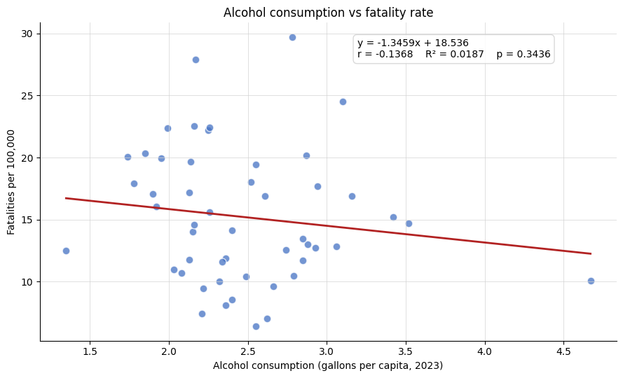

```python
r3 = regression_panel(
    panel, "alcohol_gallons_per_capita_2023", "fatalities_per_100k_1994_2015",
    "Alcohol consumption (gallons per capita, 2023)",
    "Alcohol consumption vs fatality rate",
    eq_xy=(0.55, 0.95),
)
```

**Weak negative correlation** (r ≈ -0.14). Counterintuitive at first glance, but the most likely explanation is confounding by urbanisation: states with high per-capita alcohol consumption (New Hampshire, Delaware, Nevada) tend to be denser or have heavy tourism inflows that drive up the alcohol-per-resident ratio without driving up rural-style road fatalities. Per-capita consumption is not the same as per-capita drunk driving.

### 4.4 Pickup truck share

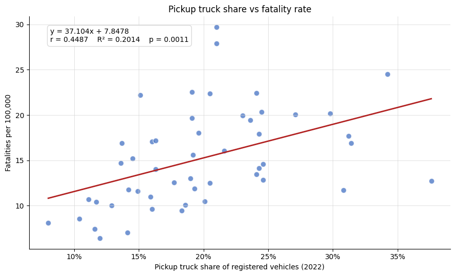

```python
r4 = regression_panel(
    panel, "pct_pickup_trucks_2022", "fatalities_per_100k_1994_2015",
    "Pickup truck share of registered vehicles (2022)",
    "Pickup truck share vs fatality rate",
    xfmt=lambda x, _: f"{x*100:.0f}%",
    eq_xy=(0.05, 0.95),
)
```

**Moderate positive correlation** (r ≈ 0.45, R² ≈ 0.20). Pickup truck share is a proxy for rural states with long driving distances on undivided roads, where single-vehicle run-off-road crashes are most fatal. It correlates with miles-per-driver: both pick up the rural-state signal.

## 5. Joint regression on the two strongest predictors

```python
X = panel[["avg_miles_per_driver_2022", "pct_pickup_trucks_2022"]]
X = sm.add_constant(X)
y = panel["fatalities_per_100k_1994_2015"]
joint_model = sm.OLS(y, X).fit()
print(joint_model.summary())
```

```
                                  OLS Regression Results
=========================================================================================
Dep. Variable:     fatalities_per_100k_1994_2015   R-squared:                       0.496
Model:                                       OLS   Adj. R-squared:                  0.474
Method:                            Least Squares   F-statistic:                     23.12
Date:                           Sun, 17 May 2026   Prob (F-statistic):           1.02e-07
Time:                                   14:44:24   Log-Likelihood:                -137.49
No. Observations:                             50   AIC:                             281.0
Df Residuals:                                 47   BIC:                             286.7
Df Model:                                      2
Covariance Type:                       nonrobust
=============================================================================================
                                coef    std err          t      P>|t|      [0.025      0.975]
---------------------------------------------------------------------------------------------
const                        -4.2598      2.921     -1.459      0.151     -10.135       1.616
avg_miles_per_driver_2022     0.0011      0.000      5.240      0.000       0.001       0.001
pct_pickup_trucks_2022       20.6490      9.121      2.264      0.028       2.300      38.998
==============================================================================
Omnibus:                        4.511   Durbin-Watson:                   1.545
Prob(Omnibus):                  0.105   Jarque-Bera (JB):                3.434
Skew:                           0.595   Prob(JB):                        0.180
Kurtosis:                       3.481   Cond. No.                     2.47e+05
==============================================================================

Notes:
[1] Standard Errors assume that the covariance matrix of the errors is correctly specified.
[2] The condition number is large, 2.47e+05. This might indicate that there are
strong multicollinearity or other numerical problems.
```

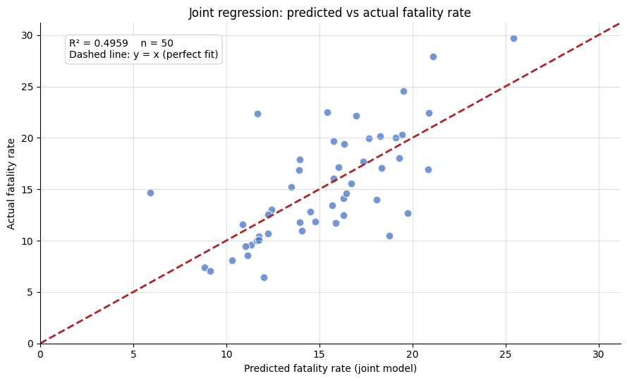

```python
# Predicted vs actual diagnostic for the joint model
y_pred = joint_model.predict(X)
joint_r_squared = joint_model.rsquared

fig, ax = plt.subplots(figsize=(9, 5.5))
ax.scatter(y_pred, y, color=SCATTER_COLOR, alpha=0.75, edgecolors="white", s=60)
lim_lo, lim_hi = 0, max(y.max(), y_pred.max()) * 1.05
ax.plot([lim_lo, lim_hi], [lim_lo, lim_hi], color=LINE_COLOR, linewidth=2, linestyle="--")
ax.set_xlabel("Predicted fatality rate (joint model)")
ax.set_ylabel("Actual fatality rate")
ax.set_title("Joint regression: predicted vs actual fatality rate", fontsize=12)
ax.text(0.05, 0.95,
        f"R² = {joint_r_squared:.4f}    n = {len(y)}\nDashed line: y = x (perfect fit)",
        transform=ax.transAxes, va="top", fontsize=10,
        bbox=dict(boxstyle="round,pad=0.4", facecolor="white", alpha=0.85, edgecolor="lightgray"))
ax.set_xlim(lim_lo, lim_hi)
ax.set_ylim(lim_lo, lim_hi)
plt.tight_layout()
plt.show()
```

The joint model achieves **R² = 0.4959**, a meaningful step up from either single predictor (miles alone: 0.4409, pickup alone: 0.2014). Both predictors retain positive coefficients with reasonable t-statistics, confirming each contributes signal even after controlling for the other.

## 6. Multivariate OLS with all four predictors

Now extend to all four predictors at once, so each coefficient is estimated controlling for the others.

```python
X = panel[["avg_miles_per_driver_2022", "police_count_2020",
           "alcohol_gallons_per_capita_2023", "pct_pickup_trucks_2022"]]
X = sm.add_constant(X)
y = panel["fatalities_per_100k_1994_2015"]
full_model = sm.OLS(y, X).fit()
print(full_model.summary())
```

```
                                  OLS Regression Results
=========================================================================================
Dep. Variable:     fatalities_per_100k_1994_2015   R-squared:                       0.508
Model:                                       OLS   Adj. R-squared:                  0.464
Method:                            Least Squares   F-statistic:                     11.60
Date:                           Sun, 17 May 2026   Prob (F-statistic):           1.48e-06
Time:                                   14:44:24   Log-Likelihood:                -136.90
No. Observations:                             50   AIC:                             283.8
Df Residuals:                                 45   BIC:                             293.4
Df Model:                                      4
Covariance Type:                       nonrobust
===================================================================================================
                                      coef    std err          t      P>|t|      [0.025      0.975]
---------------------------------------------------------------------------------------------------
const                              -2.8230      4.338     -0.651      0.518     -11.560       5.914
avg_miles_per_driver_2022           0.0011      0.000      4.901      0.000       0.001       0.001
police_count_2020               -3.109e-05   3.28e-05     -0.949      0.348   -9.71e-05    3.49e-05
alcohol_gallons_per_capita_2023    -0.4488      1.095     -0.410      0.684      -2.654       1.756
pct_pickup_trucks_2022             20.6774      9.586      2.157      0.036       1.371      39.984
==============================================================================
Omnibus:                        3.391   Durbin-Watson:                   1.514
Prob(Omnibus):                  0.183   Jarque-Bera (JB):                2.412
Skew:                           0.500   Prob(JB):                        0.299
Kurtosis:                       3.399   Cond. No.                     4.29e+05
==============================================================================

Notes:
[1] Standard Errors assume that the covariance matrix of the errors is correctly specified.
[2] The condition number is large, 4.29e+05. This might indicate that there are
strong multicollinearity or other numerical problems.
```

## Limitations

- Single-year predictors paired with a 22-year average response. A multi-year panel of both sides would be more rigorous and would surface dynamic effects.
- The 1994 to 2015 window excludes 2016 to 2022, where 2020-2021 saw a fatality spike.
- No controls for road network characteristics (rural vs urban miles), weather, or seatbelt enforcement intensity.
- 50 observations is a small sample; the multivariate model is sensitive to a handful of influential points (Wyoming, Mississippi).
- Miles-per-driver and pickup truck share both proxy for the rural-state pattern, so their joint coefficients should not be read as independent causal effects.

## How to reproduce

```
pip install -r requirements.txt
jupyter notebook analysis.ipynb
```

Render to HTML in one step:

```
jupyter nbconvert --to html --execute analysis.ipynb
```